# The Great American Coffee Taste Test

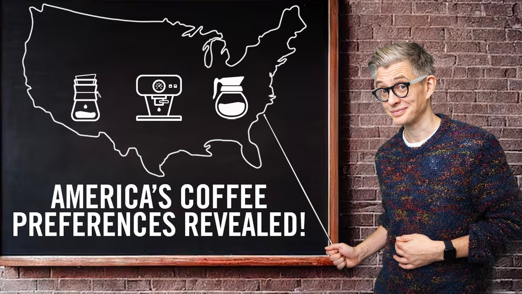

In 2023 James Hoffman surveyed 4000 US residents to understand how they enjoyed coffees A, B, C and D. He also asked some questions about their coffee consumption habits and some basic demographic data.

Watch James discuss his survey and the results [here](https://youtu.be/bMOOQfeloH0?si=da3OMVy5L4jQ5pXx). You can download the .csv of responses [here](https://bit.ly/gacttCSV).

Coffees A (light), B (medium), and C (dark) were all washed coffees but differed by roast level. Coffee D was a naturally processed coffee with more fruity, fermented flavours.

**My primary goal in this analysis is to answer 2 questions:**

- What is the consensus on the tasting notes of the different coffees?
- How does response differ among different consumers?

#### Visualisations and Analysis

- 1. What's this coffee like?
- 2. Respondents
- 3. Gender
- 4. Age
- 5. Brew Methods
- 6. Spenders
- 7. Experts?
- Conclusions

## ii.Cleaning

We have a lot of columns in our data set. But some of them contain all/mostly null values. Below I get rid of any columns that are less than 15% full then check how many are remaining.

```
Rows, Columns = (4042, 89)
```

We still have 89 columns! While some columns are irrelevant for our primary questions, they may be useful for our secondary analysis.

So, I'll rename them all to make the dataframe a bit easier to use.

### Cleaning Brew Method Data

There is a serious oversight in the questionnaire: The omission of AeroPress as a brew method. This lead to more than 2/3 of the "Other Methods" being AeroPress making it a significant brew method in it's own right (6th most popular overall). Moka was the 2nd most popular other method.

I have corrected this oversight, using regex to identify aeropress and moka users, creating their entries in new `aero_user` and `moka_user` columns and removing them from the othermethod_user column.

I have also created a column for people with no brewmethod:`non_user`

### Adding some numeric columns

For some numeric data, ranges have been given for the respondents to choose between and the data is string, not numeric e.g. age.

We need to create numeric columns that we can use for visualisations and ordering, while retaining a list of the unique values to be used as labels

### Cleaning Tasting Data

For our analysis we will need to look primarily at the tasting data. Let's make an index of columns for looking at coffees`abcd`

```
BEFORE
```

|  | a_bitterness | a_acidity | a_rating | a_notes | b_bitterness | b_acidity | b_rating | b_notes | c_bitterness | c_acidity | c_rating | c_notes | d_bitterness | d_acidity | d_rating | d_notes | abc_preference | ad_preference | abcd_preference |
| --- | --- | --- | --- | --- | --- | --- | --- | --- | --- | --- | --- | --- | --- | --- | --- | --- | --- | --- | --- |
| 0 | NaN | NaN | NaN | NaN | NaN | NaN | NaN | NaN | NaN | NaN | NaN | NaN | NaN | NaN | NaN | NaN | NaN | NaN | NaN |
| 1 | NaN | NaN | NaN | NaN | NaN | NaN | NaN | NaN | NaN | NaN | NaN | NaN | NaN | NaN | NaN | NaN | NaN | NaN | NaN |
| 2 | NaN | NaN | NaN | NaN | NaN | NaN | NaN | NaN | NaN | NaN | NaN | NaN | NaN | NaN | NaN | NaN | NaN | NaN | NaN |
| 3 | NaN | NaN | NaN | NaN | NaN | NaN | NaN | NaN | NaN | NaN | NaN | NaN | NaN | NaN | NaN | NaN | NaN | NaN | NaN |
| 4 | NaN | NaN | NaN | NaN | NaN | NaN | NaN | NaN | NaN | NaN | NaN | NaN | NaN | NaN | NaN | NaN | NaN | NaN | NaN |

Looking at the head of the tasting data above we can immediately see we are facing a few nulls.

I don't mind respondents' who haven't filled in `_notes` data, but we need a dataframe where everyone has at least filled in the numeric data, indicating they have tasted and rated **all** the coffees. Let's, call it `tasters`.

This is the data we will use most as it has information exclusively on respondents who tried the coffee.

```
AFTER
```

|  | a_bitterness | a_acidity | a_rating | a_notes | b_bitterness | b_acidity | b_rating | b_notes | c_bitterness | c_acidity | c_rating | c_notes | d_bitterness | d_acidity | d_rating | d_notes | abc_preference | ad_preference | abcd_preference |
| --- | --- | --- | --- | --- | --- | --- | --- | --- | --- | --- | --- | --- | --- | --- | --- | --- | --- | --- | --- |
| 8 | 4.0 | 4.0 | 4.0 | NaN | 4.0 | 4.0 | 4.0 | NaN | 4.0 | 4.0 | 4.0 | NaN | 4.0 | 4.0 | 4.0 | NaN | NaN | NaN | NaN |
| 16 | 3.0 | 3.0 | 3.0 | NaN | 3.0 | 3.0 | 3.0 | NaN | 3.0 | 3.0 | 3.0 | NaN | 3.0 | 3.0 | 3.0 | NaN | Coffee C | Coffee D | Coffee D |
| 17 | 3.0 | 3.0 | 3.0 | NaN | 3.0 | 3.0 | 3.0 | NaN | 3.0 | 3.0 | 3.0 | NaN | 3.0 | 3.0 | 3.0 | NaN | Coffee A | Coffee A | Coffee B |
| 34 | 3.0 | 3.0 | 4.0 | NaN | 3.0 | 3.0 | 5.0 | NaN | 4.0 | 3.0 | 3.0 | NaN | 5.0 | 2.0 | 3.0 | NaN | Coffee B | Coffee A | Coffee B |
| 41 | 1.0 | 4.0 | 4.0 | NaN | 1.0 | 4.0 | 4.0 | NaN | 1.0 | 4.0 | 4.0 | NaN | 2.0 | 4.0 | 4.0 | NaN | Coffee A | Coffee A | Coffee A |

## 1. What's this coffee like?

In this section we explore which coffee is the most popular, what are the tasting notes, and the balance of acidity-bitterness.

Back to the top

### Most popular?

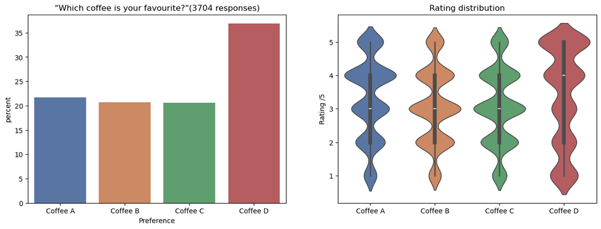

**Coffee D *__appears to be*** the clear winner! Hurrah for natural processed coffee.__

It is most frequently named as the favourite coffee, and it's ratings are largely higher than the others.

However, it is clearly not universally liked, otherwise it wouldn't have any low ratings. From the large bulge at the bottom of violin plot we can see **Coffee D has the highest number of 1/5 ratings**.

**Coffee D is the most polarizing!!!**

Although it has the most fans, it also has the most haters. It is marmite coffee.

If we look at the mean ratings, we see it is only very slightly higher than Coffee A.

|  | Mean |
| --- | --- |
| a_rating | 3.31 |
| b_rating | 3.07 |
| c_rating | 3.06 |
| d_rating | 3.38 |

By contrast A, B, and C are more commonly given mid-range ratings, they are crowd pleasers, especially A. When we think about the types of coffee we have it makes sense:

- A, B, and C are "normal" coffees just with different levels of roast
- A is a light roast, giving those fruitier tasting notes that are clearly popular in our sample
- D is a naturally processed coffee.
  - Without getting too complicated, this imparts sweet fruity flavours, but also some fermented, "funky" flavours which some people really hate.

It will be interesting how these results are affected when we start focussing on respondents differentiated by coffee drinking habits and other factors, like age and gender.

### Tasting notes?

In this section, I am going to convert the qualitative data we have in the `_notes` columns to create a `WordCloud`

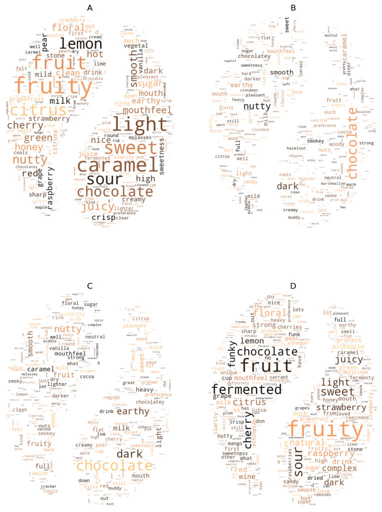

We can see that B and C are clearly exhibiting the flavours we would associate with "normal" darker roasted coffee: chocolate, nut, earthy.

Our respondents had plenty more to say about A and D, which makes sense as they were the most popular. While both were identified as fruity, A is associated more with citrusy flavours had more chocolatey caramel responses.

**While this method needs more work to identify plurals and remove words that have nothing to do with flavour, it definitely has potential value for educating consumers.**

### Acidity Bitterness Matrix

Respondents were asked to rate each coffee on how **bitter** and **acidic** they were on a scale of 1 to 5.

These are defining flavour characteristics in all coffee and too much of either can be overwhelming and, frankly, disgusting:

- bitterness is associated with flavours like nuts and chocolate, bitter coffee tends to be darker roasted
- acidity is associated with flavours like citrus, green apple, or tart berries, it tends to be lighter roasted

<sub>These flavours are also highly dependent on how the coffee is brewed, but we don't have to worry about that as the samples were pre-brewed, frozen, and sent out so everyone had the same tasting experience.</sub>

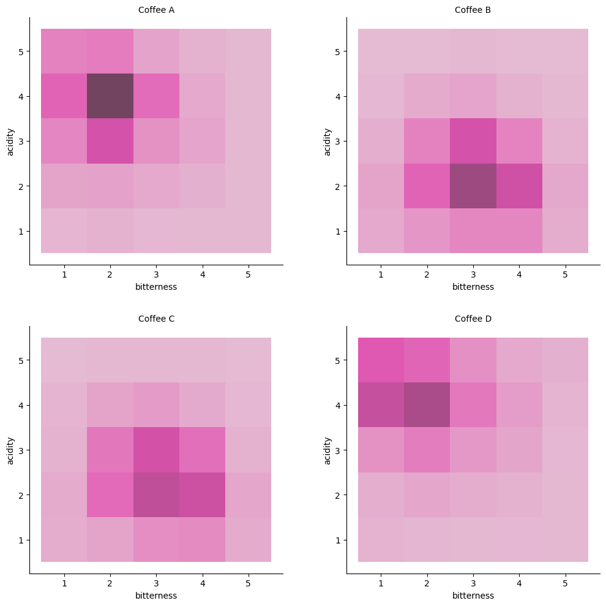

These are bivariate histograms: the darker the square the more respondents there are at those coordinates. For example, many people marked Coffee A as 2/5 bitterness, 4/5 acidic.

These histograms confirm much of what we have already discovered about these coffees. What is interesting is the strong similarities between B and C, we might have expected C to be more bitter as it is a darker roast. This method, combined with the word clouds, and similar preference data, shows that our respondents struggled to differentiate meaningfully between B and C.

## 2. Respondents

Back to the top

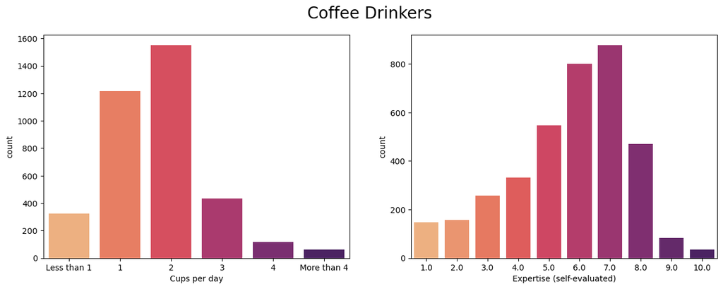

Most of our respondents drink 2 cups a day, there is a good distribution of interest/expertise level across our respondents. Most gave themselves 6 or 7/10, but please bear in mind that these are self-evaluated metrics.

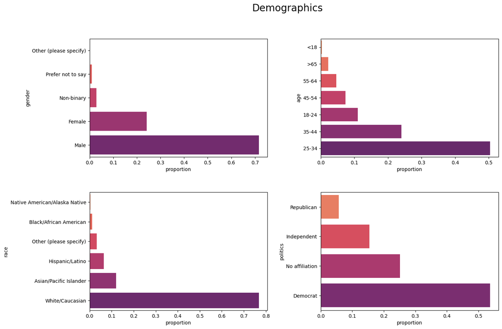

### Oh dear!

Our data set is skewed. The respondents are majority white males, mainly between the ages of 25 and 34, and mainly Democrats.

Could this have affected the results on tasting and preference?

<sub>Spoiler alert, I looked into if there was a serious correlation between political affiliation and coffee preference but there isn't. It gives an insight into the politics of our primarily young group of respondents tho. ~25% of them are not affiliated with any party and so cannot vote in primaries :(</sub>

## 3. Gender

Back to the top

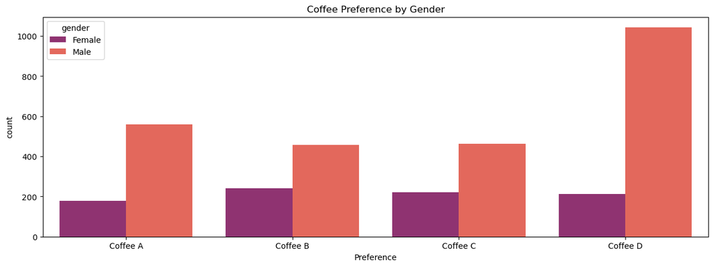

### Men like coffees A and D, women are far more evenly distributed.

Our initial conclusion that A and D were the most popular coffees may have been misguided, the data has been totally skewed by the number of men and their preferences.

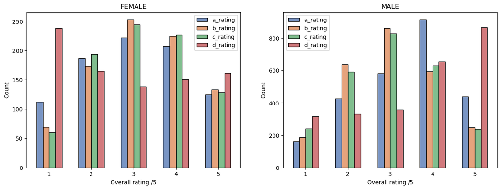

### Damn, okay, Coffee D is really polarising among women.

Look at the red bars showing how many times Coffee D received each score/5.

Coffee D is more hated than loved among female respondents

- It is most commonly rated 1/5, more than twice as much as any other coffee.
- **But** it is important to note that women also gave Coffee D more 5/5 ratings than any other coffee, reiterating its polarising nature.

Coffee A was also less popular among women, it does not have the same spike in 4/5 ratings as it does among men, and receives significantly more 1/5 ratings than Coffees B and C.

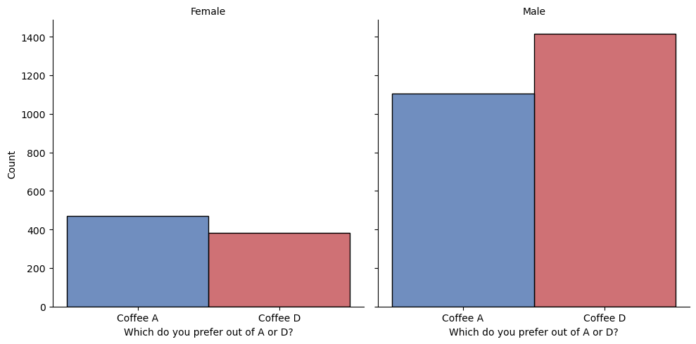

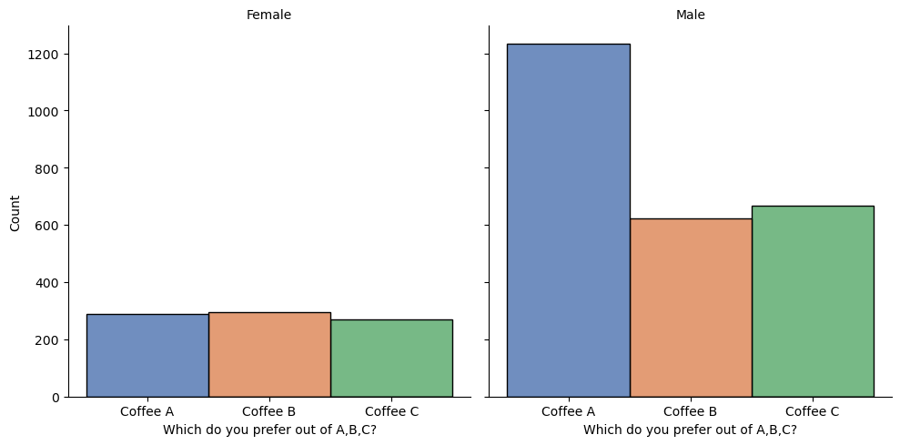

### Men are skewing the data.

Men prefer Coffee D to Coffee A, and out of just A,B,C prefer A.

Women prefer Coffee A to Coffee D, but only very marginally because, in fact, many of them just hate coffee D.

Between A,B, and C there is no clear favourite among women.

This study would benefit from more female respondents, the male preference for Coffees A and D has skewed the data in favour of these coffees.

## 4. Age

Back to the top

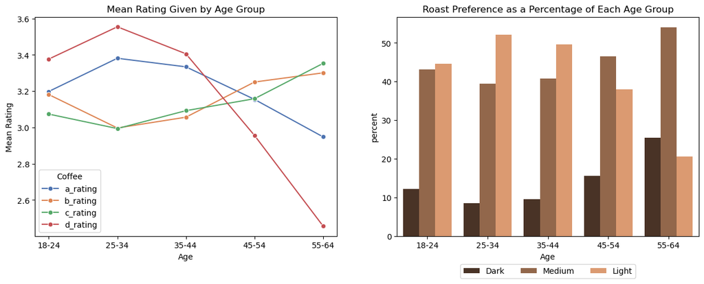

### Coffees A and D decline in popularity with age, while Coffees B and C increase.

This makes sense, especially when we look at the proportion of roast preferences in the different age groups. Older respondents react positively to more traditional, "normal" tasting coffee, reflecting their increased appetite for darker roasts.

## 5. Brew Methods

Back to the top

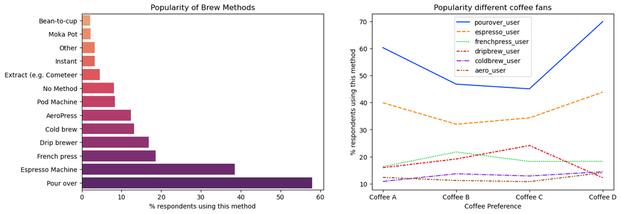

### Pour Over was the most popular brew method, followed by espresso.

This points to the type of respondent we have. Although pour over is one of the most accessible and affordable methods of specialty coffee brewing, I would not say it is massively popular among the wider population. It **is** popular among this group containing many aspiring coffee connoisseurs though.

Almost 40% of our audience also own/have access to an espresso machine, showing many respondents invest in a decent set up (more on that below).

Another clue is we have more people regularly faffing about with an aeropress than using a pod machine. Coffee nerds for sure.

French press is a ubiquitous piece of coffee brewing equipment, used by novices and non-snobby pros alike. The drip brewer is a very popular machine in America, it is the way every coffee is made in an office or suburban home in films and TV.

### When it comes to brew method among the different coffee fan groups...

We see that there is a significant increase in pour over usage among Coffee A and D fans. This makes sense, coffee A and D will be more like the coffees these respondents brew at home because pour over is popularly used to get all the nuanced flavours from lighter roasts and fruitier coffees.

Likewise it makes sense that the people who like Coffee C are keener on drip brew machines than other respondents. Drip brew is for making the most normal of normal coffee.

## 6. Spenders

Back to the top

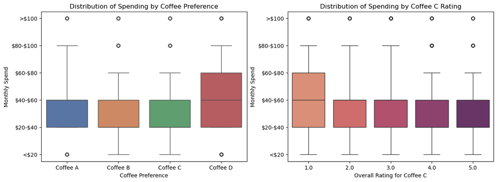

### There are outliers in every group, but Coffee D fans clearly spend more monthly on coffee.

Coffee sellers will want to catch some of that market.

There are also implications for other groups. We can see on the left that Coffee C fans don't spend as much money, but if we look deeper, on the right: we can see that the people who hate Coffee C spend more money every month than the people that like it. This makes sense as Coffee D lovers are largely Coffee C haters.

Coffee sellers may not want to capture more of the market where people don't spend much money (Coffee C fans), and prefer to cater for Coffee D lovers. But it also represents a gap in the market to squeeze more money out of people who still appreciate the classic "normal" flavours of coffee.

Coffee's B and C represent "normal" coffee that is widely available so it makes sense that people who like them won't spend as much. Whereas people that hate that kind of coffee and love new, fruity, experimental coffee are willing to pay a little more.

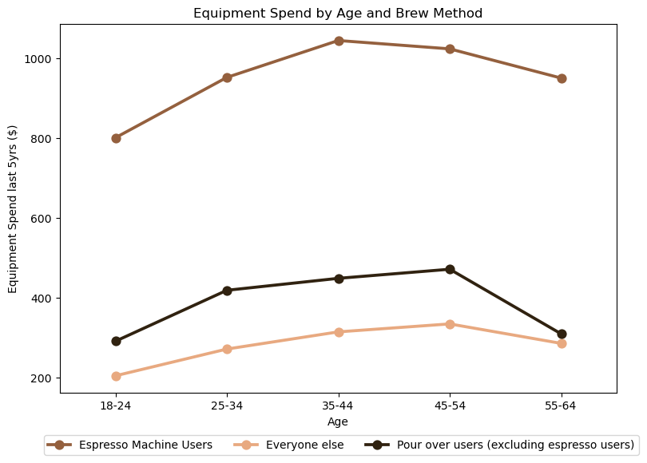

### You'll spend more if you're an espresso machine user

The difference you spend as an espresso machine user is stark peaking at middle age (when you need the most coffee and have the most disposable income).

One thing that is not explored is grinders - investment in a good grinder is something many pour over users may opt for, and will push their overall spend many times higher.

This graph uses means calculated using the midpoints of each range of options (e.g. \$500 - \$1000 --> 750) and makes an assumption of >\$1000 ---> 1500. So the actual spending figures are unlikely to be accurate, but the **comparison** between spending on different brew methods is accurate.

## 7. Experts?

Back to the top

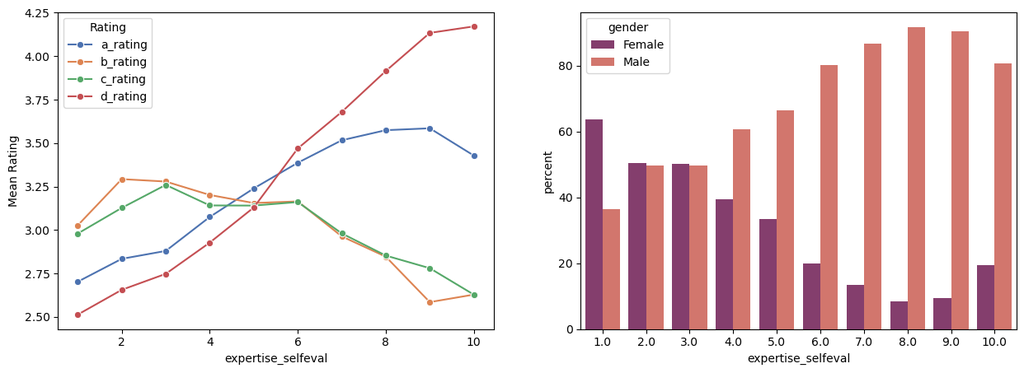

### Those who rated themselves experts rated Coffee D very highly.

They also rated Coffee A relatively highly.

```
Mean Ratings by Respondents rating their expertise >= 9/10
```

| gender | a_rating | b_rating | c_rating | d_rating | count |
| --- | --- | --- | --- | --- | --- |
| Female | 3.2 | 2.8 | 2.8 | 3.5 | 13 |
| Male | 3.6 | 2.6 | 2.8 | 4.2 | 92 |

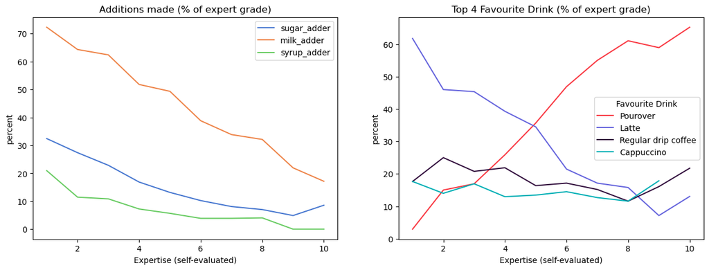

### Experts like their coffee unadulterated.

The percentage of respondents adding anything to their coffee declines as expertise increases. Unsurprisingly, the percentage of people who drink pour overs increases; pour over is frequently enjoyed as a form of coffee unadulterated by milk or any other flavouring.

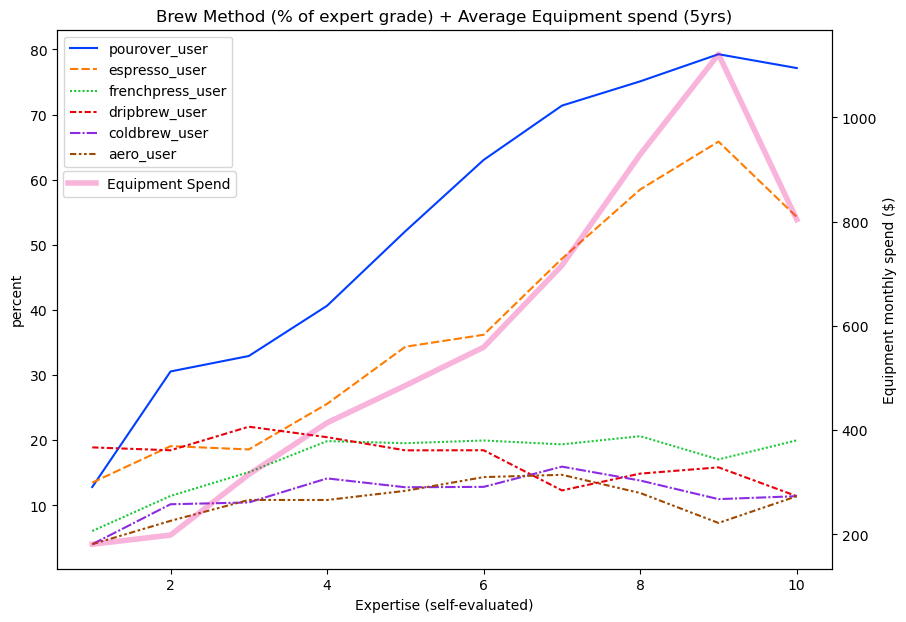

### Most experts use espresso machines and pour overs.

Unsurprisingly, they spend more money on equipment too.

# Conclusions

Coffee D is clearly an exciting, flavourful coffee that will appeal to younger coffee nerds willing to pay for something special.

**But**, it will not appeal to everyone and the likely cost will also put off a lot of people. Furthermore, fruity coffees tend to be best as straight pour overs and the acidic flavours interact terribly with milk. So the large numbers respondents who love a milky coffee need a coffee that works well in all the classic espresso based drinks (Cappucino, Latte etc.)

If I had to choose only 1 other coffee, it would be Coffee B.

- It is widely liked in different age ranges
- Women like it (it received the 2nd highest number of 5/5 ratings and was narrowly the favourite out of A,B,C)
- Although it was hard to distinguish from C, it *is* marketed as a medium roast which many respondents indicated was their preferred roast.
- The flavour profiles identified in the wordcloud were positive and would pair well with milk

The second choice among experts was Coffee A, but women do not like this coffee, and I would suggest that, similar to D, it is best as a pour over.